# Assignment 3

Welcome to Assignment 3. This will be even more fun. Now we will calculate statistical measures on the test data you have created.

YOU ARE NOT ALLOWED TO USE ANY OTHER 3RD PARTY LIBRARIES LIKE PANDAS. PLEASE ONLY MODIFY CONTENT INSIDE THE FUNCTION SKELETONS Please read why: https://www.coursera.org/learn/exploring-visualizing-iot-data/discussions/weeks/3/threads/skjCbNgeEeapeQ5W6suLkA . Just make sure you hit the play button on each cell from top to down. There are seven functions you have to implement. Please also make sure than on each change on a function you hit the play button again on the corresponding cell to make it available to the rest of this notebook. Please also make sure to only implement the function bodies and DON'T add any additional code outside functions since this might confuse the autograder.

All functions can be implemented using DataFrames, ApacheSparkSQL or RDDs. We are only interested in the result. You are given the reference to the data frame in the "df" parameter and in case you want to use SQL just use the "spark" parameter which is a reference to the global SparkSession object. Finally if you want to use RDDs just use "df.rdd" for obtaining a reference to the underlying RDD object.

Let's start with the first function. Please calculate the minimal temperature for the test data set you have created. We've provided a little skeleton for you in case you want to use SQL. You can use this skeleton for all subsequent functions. Everything can be implemented using SQL only if you like.

```python
def minTemperature(df,spark):
    df.createOrReplaceTempView("parquetFile")
    mintemp= spark.sql("SELECT min(temperature) as mintemp FROM parquetFile where temperature is not null").first().mintemp
    return mintemp
```

Please now do the same for the mean of the temperature

```python
def meanTemperature(df,spark):
    df.createOrReplaceTempView("parquetFile")
    return spark.sql("SELECT avg(temperature) as avg FROM parquetFile where temperature is not null").first().avg
```

Please now do the same for the maximum of the temperature

```python
def maxTemperature(df,spark):
    df.createOrReplaceTempView("parquetFile")
    return spark.sql("SELECT max(temperature) as max FROM parquetFile where temperature is not null").first().max
```

Please now do the same for the standard deviation of the temperature

```python
def sdTemperature(df,spark):
    df.createOrReplaceTempView("parquetFile")
    return spark.sql("SELECT std(temperature) as std FROM parquetFile where temperature is not null").first().std
```

Please now do the same for the skew of the temperature. Since the SQL statement for this is a bit more complicated we've provided a skeleton for you. You have to insert custom code at four position in order to make the function work. Alternatively you can also remove everything and implement if on your own. Note that we are making use of two previously defined functions, so please make sure they are correct. Also note that we are making use of python's string formatting capabilitis where the results of the two function calls to "meanTemperature" and "sdTemperature" are inserted at the "%s" symbols in the SQL string.

```python
def skewTemperature(df,spark):
    df.createOrReplaceTempView("parquetFile")
    return spark.sql("""
SELECT
    (
        1/count(temperature)
    ) *
    SUM (
        POWER(temperature -%s,3)/POWER(%s,3)
    )

as skewt from parquetFile
                    """ %(meanTemperature(df,spark),sdTemperature(df,spark))).first().skewt
```

Kurtosis is the 4th statistical moment, so if you are smart you can make use of the code for skew which is the 3rd statistical moment. Actually only two things are different.

```python
def kurtosisTemperature(df,spark):
    df.createOrReplaceTempView("parquetFile")
    return spark.sql("""
SELECT
    (
        1/count(temperature)
    ) *
    SUM (
        POWER(temperature -%s,4)/POWER(%s,4)
    )

as kurtosis from parquetFile
                    """ %(meanTemperature(df,spark),sdTemperature(df,spark))).first().kurtosis
```

Just a hint. This can be solved easily using SQL as well, but as shown in the lecture also using RDDs.

```python
def correlationTemperatureHardness(df,spark):
    df.createOrReplaceTempView("parquetFile")
    return spark.sql("SELECT corr(temperature, hardness) as corr FROM parquetFile").first().corr
```

### PLEASE DON'T REMOVE THIS BLOCK - THE FOLLOWING CODE IS NOT GRADED

# axx

### PLEASE DON'T REMOVE THIS BLOCK - THE FOLLOWING CODE IS NOT GRADED

Now it is time to connect to the object store and read a PARQUET file and create a dataframe out of it. We've created that data for you already. Using SparkSQL you can handle it like a database.

```python
import ibmos2spark

# @hidden_cell
credentials = {
    'endpoint': 'https://s3-api.us-geo.objectstorage.service.networklayer.com',
    'api_key': 'PUJMZf9PLqN4y-6NUtVlEuq6zFoWhfuecFVMYLBrkxrT',
    'service_id': 'iam-ServiceId-9cd8e66e-3bb4-495a-807a-588692cca4d0',
    'iam_service_endpoint': 'https://iam.bluemix.net/oidc/token'}

configuration_name = 'os_b0f1407510994fd1b793b85137baafb8_configs'
cos = ibmos2spark.CloudObjectStorage(sc, credentials, configuration_name, 'bluemix_cos')

from pyspark.sql import SparkSession
spark = SparkSession.builder.getOrCreate()
# Since JSON data can be semi-structured and contain additional metadata, it is possible that you might face issues with the DataFrame layout.
# Please read the documentation of 'SparkSession.read()' to learn more about the possibilities to adjust the data loading.
# PySpark documentation: http://spark.apache.org/docs/2.0.2/api/python/pyspark.sql.html#pyspark.sql.DataFrameReader.json

df = spark.read.parquet(cos.url('washing.parquet', 'courseradsnew-donotdelete-pr-1hffrnl2pprwut'))
df.show()
```

```
+--------------------+--------------------+-----+--------+----------+---------+--------+-----+-----------+-------------+-------+
|                 _id|                _rev|count|flowrate|fluidlevel|frequency|hardness|speed|temperature|           ts|voltage|
+--------------------+--------------------+-----+--------+----------+---------+--------+-----+-----------+-------------+-------+
|0d86485d0f88d1f9d...|1-57940679fb8a713...|    4|      11|acceptable|     null|      77| null|        100|1547808723923|   null|
|0d86485d0f88d1f9d...|1-15ff3a0b304d789...|    2|    null|      null|     null|    null| 1046|       null|1547808729917|   null|
|0d86485d0f88d1f9d...|1-97c2742b68c7b07...|    4|    null|      null|       71|    null| null|       null|1547808731918|    236|
|0d86485d0f88d1f9d...|1-eefb903dbe45746...|   19|      11|acceptable|     null|      75| null|         86|1547808738999|   null|
|0d86485d0f88d1f9d...|1-5f68b4c72813c25...|    7|    null|      null|       75|    null| null|       null|1547808740927|    235|
|0d86485d0f88d1f9d...|1-cd4b6c57ddbe77e...|    5|    null|      null|     null|    null| 1014|       null|1547808744923|   null|
|0d86485d0f88d1f9d...|1-a35b25b5bf43aaf...|   32|      11|acceptable|     null|      73| null|         84|1547808752028|   null|
|0d86485d0f88d1f9d...|1-b717f7289a8476d...|   48|      11|acceptable|     null|      79| null|         84|1547808768065|   null|
|0d86485d0f88d1f9d...|1-c2f1f8fcf178b2f...|   18|    null|      null|       73|    null| null|       null|1547808773944|    228|
|0d86485d0f88d1f9d...|1-15033dd9eebb4a8...|   59|      11|acceptable|     null|      72| null|         96|1547808779093|   null|
|0d86485d0f88d1f9d...|1-753dae825f9a6c2...|   62|      11|acceptable|     null|      73| null|         88|1547808782113|   null|
|0d86485d0f88d1f9d...|1-b168089f44f03f0...|   13|    null|      null|     null|    null| 1097|       null|1547808784940|   null|
|0d86485d0f88d1f9d...|1-403b687c6be0dea...|   23|    null|      null|       80|    null| null|       null|1547808788955|    236|
|0d86485d0f88d1f9d...|1-195551e0455a24b...|   72|      11|acceptable|     null|      77| null|         87|1547808792134|   null|
|0d86485d0f88d1f9d...|1-060a39fc6c2ddee...|   26|    null|      null|       62|    null| null|       null|1547808797959|    233|
|0d86485d0f88d1f9d...|1-2234514bffee465...|   27|    null|      null|       61|    null| null|       null|1547808800960|    226|
|0d86485d0f88d1f9d...|1-4265898bb401db0...|   82|      11|acceptable|     null|      79| null|         96|1547808802154|   null|
|0d86485d0f88d1f9d...|1-2fbf7ca9a0425a0...|   94|      11|acceptable|     null|      73| null|         90|1547808814186|   null|
|0d86485d0f88d1f9d...|1-203c0ee6d7fbd21...|   97|      11|acceptable|     null|      77| null|         88|1547808817190|   null|
|0d86485d0f88d1f9d...|1-47e1965db94fcab...|  104|      11|acceptable|     null|      75| null|         80|1547808824198|   null|
+--------------------+--------------------+-----+--------+----------+---------+--------+-----+-----------+-------------+-------+
only showing top 20 rows
```

```python
minTemperature(df,spark)
```

```
80
```

```python
meanTemperature(df,spark)
```

```
90.03800298062593
```

```python
maxTemperature(df,spark)
```

```
100
```

```python
sdTemperature(df,spark)
```

```
6.1007610586219725
```

```python
skewTemperature(df,spark)
```

```
0.010398374583336334
```

```python
kurtosisTemperature(df,spark)
```

```
1.773427150876985
```

```python
arr = [34,1,23,4,3,3,12,4,3,1]
rddX  = sc.parallelize(arr)
```

```python
mean  = rddX.sum()/float(rddX.count())
```

```python
#standard devitaion
from math import sqrt, pow
n=rddX.count()
sd = sqrt(rddX.map(lambda x: pow(x-mean,2)).sum()/n)
sd
```

```
10.562196741208714
```

```python
n= float(n)
skewness = n/((n-1)*(n-2))*rddX.map(lambda x: pow(x-mean,3)/ pow(sd,3)).sum()
skewness
```

```
2.0207040735991666
```

```python
kurtosis = rddX.map(lambda x: pow(x-mean,4)/pow(sd, 4)).sum()/(n)
kurtosis
```

```
3.663124005193276
```

```python
correlationTemperatureHardness(df,spark)
```

```
0.017754069047296324
```

```python
df.createOrReplaceTempView("parquetFile")
res = spark.sql("select temperature as temp from parquetFile where temperature is not null")
#res_arr= res.rdd.map(lambda row: row.temperature).sample(False, 0.1).collect()
```

```python
res.rdd.map(lambda row : row.temp).take(10)
```

```
[100, 86, 84, 84, 96, 88, 87, 96, 90, 88]
```

```python
res_arr =res.rdd.map(lambda row : row.temp).sample(False, 0.1).collect()
```

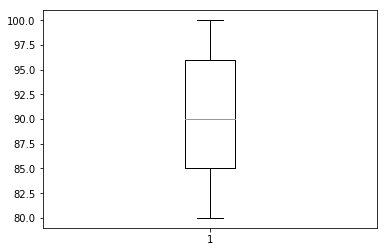

```python
import matplotlib.pyplot as plt
plt.boxplot(res_arr)
plt.show()
```

```python
res_v = spark.sql("select voltage, ts from parquetFile where voltage is not null order by ts asc")
result_rdd= res_v.rdd.sample(False, 0.1).map(lambda row: (row.ts,row.voltage))
result_array_voltage = result_rdd.map(lambda x: x[0]).collect()
result_array_ts = result_rdd.map(lambda x: x[1]).collect()
result_array_ts
```

```
[234,
 227,
 239,
 220,
 227,
 226,
 235,
 220,
 228,
 236,
 236,
 223,
 228,
 253,
 250,
 221,
 232,
 227,
 220,
 226,
 229,
 230,
 224,
 232,
 236,
 231,
 228,
 221,
 254,
 224,
 229,
 228,
 221,
 221,
 232,
 231,
 225,
 251,
 237,
 238,
 227,
 221,
 221,
 232,
 232,
 228,
 226,
 232]
```

[figure not shown]

```python
#run chart
import matplotlib.pyplot as plt
plt.plot(result_array_ts, result_array_voltage)
plt.xlabel("time")
plt.ylabel("voltage")
plt.show()
```

```python
#scatterplot of individual datapoints addressed by 2 or 3 dimensions
# serves for classification, clusters or anomalies
res_df = spark.sql("select hardness, temperature, flowrate from parquetFile where hardness is not null")
result_rdd2= res_df.rdd.sample(False, 0.1).map(lambda row: (row.temperature,row.flowrate, row.hardness))
result_array_hardness = result_rdd2.map(lambda x: x[0]).collect()
result_array_flowrate = result_rdd2.map(lambda x: x[1]).collect()
result_array_temperature = result_rdd2.map(lambda x: x[2]).collect()
result_array_temperature
```

```
[79,
 160,
 77,
 120,
 78,
 70,
 70,
 79,
 71,
 103,
 73,
 77,
 80,
 72,
 71,
 73,
 108,
 71,
 77,
 74,
 73,
 135,
 74,
 145,
 74,
 73,
 115,
 74,
 75,
 75,
 79,
 73,
 74,
 73,
 80,
 72,
 77,
 79,
 73,
 79,
```

[output cut: 67 more lines]

```
 78,
 79,
 73,
 73,
 78,
 78,
 75,
 78,
 75,
 74,
 135,
 70,
 145,
 76,
 88]
```

```
Text(0.5,0,'flowrate')
```

[figure not shown]

```python
from mpl_toolkits.mplot3d import Axes3D

fig = plt.figure()
ax = fig.add_subplot(111, projection='3d')

ax.scatter(result_array_hardness, result_array_flowrate, result_array_temperature, c='r', marker='o')

ax.set_xlabel('hardness')
ax.set_ylabel('temperature')
ax.set_xlabel('flowrate')
```

```
<function matplotlib.pyplot.show>
```

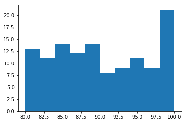

```python
#histograms to see distribution
plt.hist(result_array_hardness)
plt.show
```

Congratulations, you are done, please download this notebook as python file using the export function and submit is to the gader using the filename "assignment3.1.py"